# KNN (K-Nearest Neighbours)

Hannah Pahama

February 2025

## 1. Setup

```r
wine <- readRDS(gzcon(url("https://github.com/cd-public/D505/raw/master/dat/pinot.rds")))

# Peeking at variable types first before anything
variable_classes <- data.frame(
  Variable = colnames(wine),
  Class = sapply(wine, class)
)
print(variable_classes)
```

```
##                Variable     Class
## id                   id   integer
## province       province character
## price             price   numeric
## points           points   numeric
## year               year   numeric
## description description character
```

## 2. KNN Concepts

TODO: Explain how the choice of K affects the quality of your prediction when using a Nearest Neighbors algorithm.

Explanation:  
- A lower K value (e.g., K=1) can lead to overfitting because predictions are too sensitive to noise. - A higher K value smooths predictions but may cause underfitting. - Choosing an optimal K using cross-validation helps balance bias and variance.

## 3. Feature Engineering

Before everything else…

```r
wine <- wine %>%
  mutate(
    year_factor = factor(year),
    description = tolower(description),
    has_cherry = str_detect(description,
                            "cherry"),

    has_chocolate = str_detect(description,
                               "chocolate"),

    has_earth = str_detect(description,
                           "earth"),

    cherry_year = year * has_cherry,
    chocolate_year = year * has_chocolate,
    earth_year = year * has_earth
  ) %>%
  select(-description)

head(wine)
```

```
##   id   province price points year year_factor has_cherry has_chocolate
## 1  1     Oregon    65     87 2012        2012      FALSE         FALSE
## 2  2     Oregon    20     87 2013        2013      FALSE          TRUE
## 3  3 California    69     87 2011        2011      FALSE         FALSE
## 4  4     Oregon    50     86 2010        2010      FALSE         FALSE
## 5  5     Oregon    22     86 2009        2009      FALSE         FALSE
## 6  6     Oregon    25     86 2015        2015      FALSE         FALSE
##   has_earth cherry_year chocolate_year earth_year
## 1      TRUE           0              0       2012
## 2     FALSE           0           2013          0
## 3      TRUE           0              0       2011
## 4     FALSE           0              0          0
## 5      TRUE           0              0       2009
## 6     FALSE           0              0          0
```

```r
# Summarize the transformed data
# Summarize the transformed data
summary(wine)
```

```
##        id         province             price             points
##  Min.   :   1   Length:8380        Min.   :   7.00   Min.   :80.00
##  1st Qu.:2096   Class :character   1st Qu.:  31.00   1st Qu.:88.00
##  Median :4190   Mode  :character   Median :  45.00   Median :90.00
##  Mean   :4190                      Mean   :  52.52   Mean   :89.98
##  3rd Qu.:6285                      3rd Qu.:  60.00   3rd Qu.:92.00
##  Max.   :8380                      Max.   :2500.00   Max.   :98.00
##
##       year       year_factor   has_cherry      has_chocolate   has_earth
##  Min.   :1996   2014   :2046   Mode :logical   Mode :logical   Mode :logical
##  1st Qu.:2011   2013   :1819   FALSE:4955      FALSE:7827      FALSE:6907
##  Median :2013   2012   :1505   TRUE :3425      TRUE :553       TRUE :1473
##  Mean   :2012   2015   : 815
##  3rd Qu.:2014   2011   : 582
##  Max.   :2015   2010   : 502
##                 (Other):1111
##   cherry_year     chocolate_year     earth_year
##  Min.   :   0.0   Min.   :   0.0   Min.   :   0.0
##  1st Qu.:   0.0   1st Qu.:   0.0   1st Qu.:   0.0
##  Median :   0.0   Median :   0.0   Median :   0.0
##  Mean   : 822.5   Mean   : 132.7   Mean   : 353.7
##  3rd Qu.:2012.0   3rd Qu.:   0.0   3rd Qu.:   0.0
##  Max.   :2015.0   Max.   :2015.0   Max.   :2015.0
##
```

```r
# Check the distribution of new binary features
table(wine$has_cherry)
```

```
##
## FALSE  TRUE
##  4955  3425
```

```r
table(wine$has_chocolate)
```

```
##
## FALSE  TRUE
##  7827   553
```

```r
table(wine$has_earth)
```

```
##
## FALSE  TRUE
##  6907  1473
```

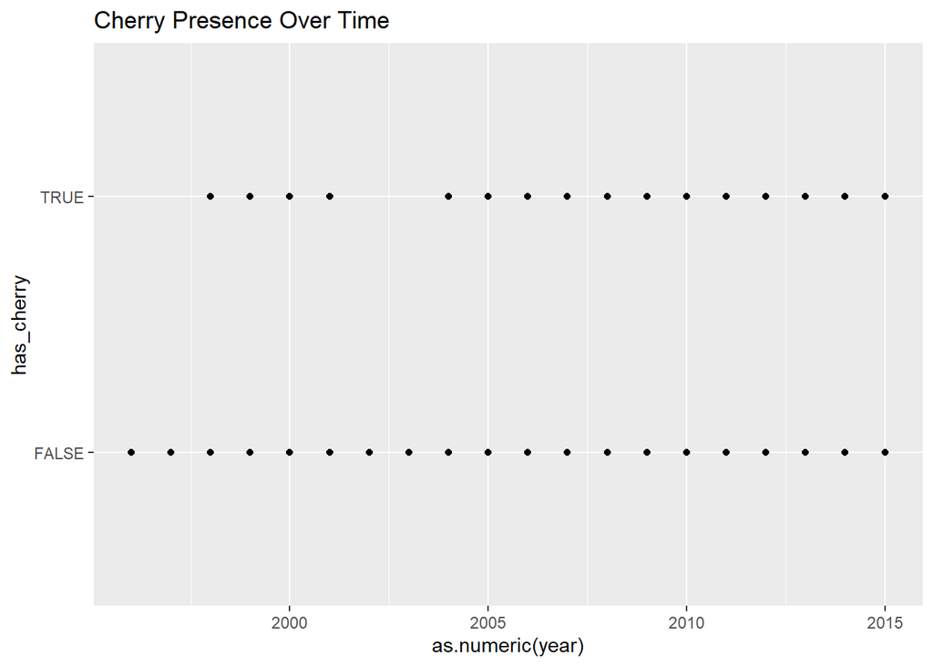

```r
# Visualize the interaction features over time
ggplot(wine,
       aes(x = as.numeric(year),
           y = has_cherry)) +
  geom_point() +
  labs(title = "Cherry Presence Over Time")
```

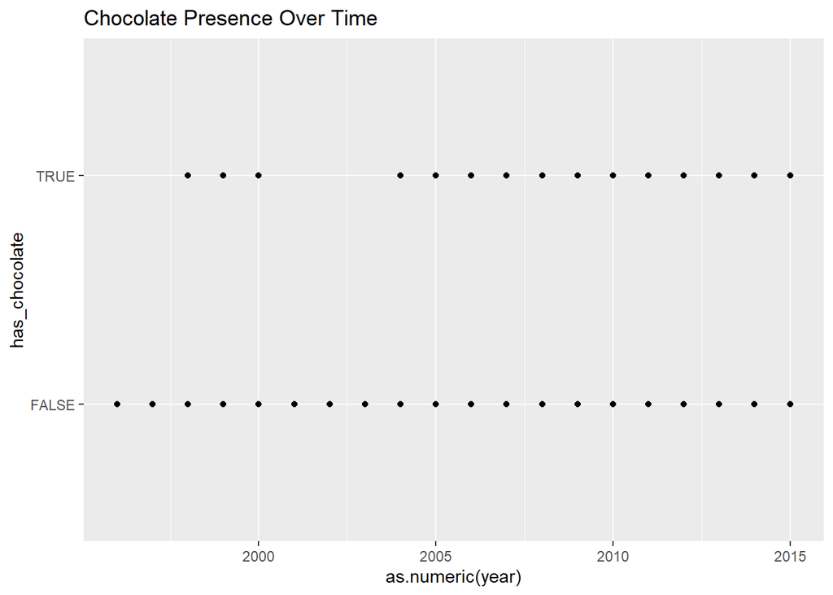

```r
ggplot(wine,
       aes(x = as.numeric(year),
           y = has_chocolate)) +
  geom_point() +
  labs(title = "Chocolate Presence Over Time")
```

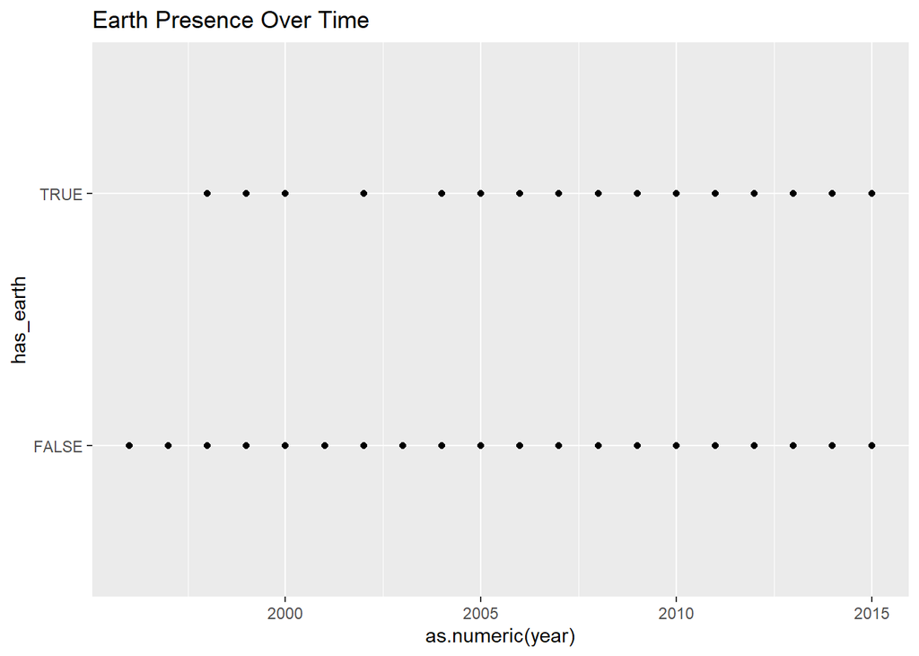

```r
ggplot(wine,
       aes(x = as.numeric(year),
           y = has_earth)) +
  geom_point() +
  labs(title = "Earth Presence Over Time")
```

## 4. Preprocessing

```r
library(caret)
library(fastDummies)

wine <- wine %>%
  preProcess(method = c("BoxCox",
                        "center",
                        "scale")) %>%
  predict(wine) %>%
  dummy_cols(select_columns = "year_factor",
             remove_most_frequent_dummy = TRUE,
             remove_selected_columns = TRUE)

# View the transformed data
head(wine)
```

```
##          id   province      price    points        year has_cherry
## 1 -2.206642     Oregon  0.7146905 -1.033841 -0.03425331      FALSE
## 2 -2.202427     Oregon -1.4139991 -1.033841  0.33313680      FALSE
## 3 -2.198830 California  0.8225454 -1.033841 -0.40146088      FALSE
## 4 -2.195581     Oregon  0.2408520 -1.367723 -0.76848588      FALSE
## 5 -2.192571     Oregon -1.2418658 -1.367723 -1.13532834      FALSE
## 6 -2.189736     Oregon -1.0109945 -1.367723  1.06846470      FALSE
##   has_chocolate has_earth cherry_year chocolate_year earth_year
## 1         FALSE      TRUE  -0.8313464     -0.2657899   2.165110
## 2          TRUE     FALSE  -0.8313464      3.7646929  -0.461775
## 3         FALSE      TRUE  -0.8313464     -0.2657899   2.163804
## 4         FALSE     FALSE  -0.8313464     -0.2657899  -0.461775
## 5         FALSE      TRUE  -0.8313464     -0.2657899   2.161193
## 6         FALSE     FALSE  -0.8313464     -0.2657899  -0.461775
##   year_factor_1996 year_factor_1997 year_factor_1998 year_factor_1999
```

[output cut: 34 more lines]

## 5. Running KNN

```r
# Split the data into 80/20 training and test sets
split <- createDataPartition(wine$province,
                             p = 0.8,
                             list = FALSE)
train <- wine[split, ]
test <- wine[-split, ]

# Train the NN model with cross-validation
fit <- train(province ~ .,
             data = train,
             method = "knn",
             tuneLength = 15,
             metric = "Kappa",
             trControl = trainControl(method = "cv",
                                      number = 5))

# Make predictions and get confusion matrix
conf_matrix <- confusionMatrix(predict(fit, test),
                               factor(test$province))

# Display key metrics (Accuracy and Kappa)
cat("Accuracy: ", conf_matrix$overall['Accuracy'], "\n")
```

```
## Accuracy:  0.6294082
```

```r
cat("Kappa: ", conf_matrix$overall['Kappa'], "\n")
```

```
## Kappa:  0.3795004
```

## 6. Kappa

TODO: Explain how to determine whether a Kappa value represents a good, bad, or other outcome.

Explanation:  
- Kappa measures agreement between predicted and actual values, adjusting for chance.  
- Values closer to 1 indicate better agreement, while values near 0 suggest predictions are no better than random guessing.  
- General interpretation:  
- < 0.2 → Poor  
- 0.2 - 0.4 → Fair  
- 0.4 - 0.6 → Moderate  
- 0.6 - 0.8 → Substantial  
- 0.8 - 1.0 → Almost perfect

## 7. Improvement

TODO: Explain how to interpret the confusion matrix and how to improve predictions. Confusion Matrix Interpretation:

TP (True Positive): Correct positives. TN (True Negative): Correct negatives. FP (False Positive): Incorrect positives. FN (False Negative): Incorrect negatives.

Improvements: - If many misclassifications exist in the confusion matrix, adjusting K might help. - Standardizing and normalizing data can improve accuracy. - Adding or engineering new features (e.g., interactions) could refine predictions. - Using weighted KNN (where closer neighbors have more influence) can help in cases of uneven class distribution.